# Multiple Sequence Alignment of GAT201 homologs

Edward Wallace

2023-10-10

# Summary

This file takes selected fungal homologs of GAT201 with the same domain structure. It performs a multiple sequence alignment of these homologs.

The output multiple sequence alignment can then be used to calculate a phylogenetic tree.

# Load gene data

Also add some display names of format “Organism, gene name”, to use in figures later

```r
uniprot_df <- here::here("data","PTHR45658_subfamilies_uniprot_info_sequences.txt") %>%
  readr::read_tsv(comment = "#") %>%
  # Next line adds DisplayName
  dplyr::mutate(DisplayName =
                  paste(
                    genus   = paste0(str_sub(Organism, end = 1), "."),
                    species = str_extract(Organism, "\\b[a-z]+\\b"),
                    gene   = str_extract(GeneNames, "[\\w-]+\\b")
                  ) %>%
                  # name C. deneoformans GAT201 and GAT204
                  str_replace("CNC06330", "GAT201") %>%
                  str_replace("CNB00390", "GAT204") %>%
                  # remove DRAFT from DICPUDRAFT and BATDEDRAFT
                  str_remove("DRAFT")
  )
uniprot_df
```

```
## # A tibble: 46 × 13
##    GeneID  UniprotID Reviewed UniprotName ProteinNames GeneNames Organism Length
##    <chr>   <chr>     <chr>    <chr>       <chr>        <chr>     <chr>     <dbl>
##  1 S00000… P40209    reviewed GAT2_YEAST  Protein GAT2 GAT2 YMR… Sacchar…    560
##  2 S00000… Q07928    reviewed GAT3_YEAST  Protein GAT3 GAT3 YLR… Sacchar…    141
##  3 S00000… P40569    reviewed GAT4_YEAST  Protein GAT4 GAT4 YIR… Sacchar…    121
##  4 CAL000… Q5ALK1    unrevie… Q5ALK1_CAN… GATA-type d… CAALFM_C… Candida…    442
##  5 CAL000… Q59LY1    reviewed BRG1_CANAL  Biofilm reg… BRG1 GAT… Candida…    422
##  6 NCU009… P78714    reviewed WC2_NEUCR   White colla… wc-2 B13… Neurosp…    530
##  7 SNOG_1… Q0U225    unrevie… Q0U225_PHA… White colla… SNOG_141… Phaeosp…    500
##  8 UMAG_0… A0A0D1CR… unrevie… A0A0D1CRW9… Zinc finger… UMAG_026… Ustilag…    925
##  9 UMAG_0… A0A0D1D1… unrevie… A0A0D1D1N3… GATA-type d… UMAG_007… Ustilag…   1436
## 10 UMAG_0… A0A0D1DT… unrevie… A0A0D1DT11… GATA-type d… UMAG_057… Ustilag…    529
## # ℹ 36 more rows
## # ℹ 5 more variables: ORFNames <chr>, Sequence <chr>, PANTHER <chr>,
## #   InterPro <chr>, DisplayName <chr>
```

# Filter genes to those with only GATA domains

We exclude homologs with other domains, including white-collar 2 (wc-2, lreB, etc.) that have an additional PAS domain.

The relevant interpro domains are `IPR000679;IPR013088;`. These are two overlapping homologous superfamilies:

- [IPR000679 is Zinc finger, GATA-type](https://www.ebi.ac.uk/interpro/entry/InterPro/IPR000679/)
- [IPR013088 is Zinc finger, NHR/GATA-type](https://www.ebi.ac.uk/interpro/entry/InterPro/IPR013088/) is the larger superfamily.

```r
gata_domains <- "IPR000679;IPR013088;"

uniprot_df_gataonly <- uniprot_df %>%
  dplyr::filter(InterPro == gata_domains)

uniprot_df_gataonly %>%
  dplyr::select(GeneID, UniprotID, Organism, Length) %>%
  print(n = 40)
```

```
## # A tibble: 37 × 4
##    GeneID            UniprotID  Organism                                  Length
##    <chr>             <chr>      <chr>                                      <dbl>
##  1 S000004744        P40209     Saccharomyces cerevisiae (strain ATCC 20…    560
##  2 S000004003        Q07928     Saccharomyces cerevisiae (strain ATCC 20…    141
##  3 S000001452        P40569     Saccharomyces cerevisiae (strain ATCC 20…    121
##  4 CAL0000198820     Q5ALK1     Candida albicans (strain SC5314 / ATCC M…    442
##  5 CAL0000196982     Q59LY1     Candida albicans (strain SC5314 / ATCC M…    422
##  6 UMAG_00706        A0A0D1D1N3 Ustilago maydis (strain 521 / FGSC 9021)…   1436
##  7 UMAG_05773        A0A0D1DT11 Ustilago maydis (strain 521 / FGSC 9021)…    529
##  8 CNC06330          Q5KJJ5     Cryptococcus neoformans var. neoformans …    438
##  9 UMAG_04076        A0A0D1DZU2 Ustilago maydis (strain 521 / FGSC 9021)…    695
## 10 BATDEDRAFT_21487  F4NTF6     Batrachochytrium dendrobatidis (strain J…    582
## 11 DDB_G0277591      Q75JZ0     Dictyostelium discoideum (Social amoeba)     519
## 12 DDB_G0282811      Q5KSV0     Dictyostelium discoideum (Social amoeba)     650
```

[output cut: 25 more lines]

## Extract Sequences only and save to fasta

```r
seqs_full_gataonly <- Biostrings::AAStringSet(x = uniprot_df_gataonly$Sequence) %>%
  setNames(nm = uniprot_df_gataonly$UniprotID)

writeXStringSet(x = seqs_full_gataonly,
                filepath = here::here("data","thirtysevenhomologs_1GATAdomainonly.fasta"))
```

# Multiple sequence alignment with Muscle

```r
seqs_full_gataonly_muscle <- msa(inputSeqs = seqs_full_gataonly, method = "Muscle") %>%
  as("AAStringSet")

seqs_full_gataonly_muscle %>%
  writeXStringSet(filepath = here::here("results","thirtysevenhomologs_1GATAdomainonly_muscle.fasta"))
```

# Multiple sequence alignment with MAFFT (on command line)

This uses default values.

```r
mafft_command <-
  paste("mafft",
        here::here("data","thirtysevenhomologs_1GATAdomainonly.fasta"),
        ">",
        here::here("results","thirtysevenhomologs_1GATAdomainonly_mafftdefault.fasta"))

print(mafft_command)
```

```
## [1] "mafft /Users/ewallac2/Repos/Gat201homology_2022/data/thirtysevenhomologs_1GATAdomainonly.fasta > /Users/ewallac2/Repos/Gat201homology_2022/results/thirtysevenhomologs_1GATAdomainonly_mafftdefault.fasta"
```

```r
system(mafft_command)
```

These multiple sequence alignments both (by visual inspection) fail to completely align the zinc-finger domains. So we have to try a different approach.

# Multiple sequence alignment with MAFFT using an alignment seed

This changes 3 values:

- `--localpair` to use the most accurate alignment
- `--seed nhrgatadomain_muscle.fasta` to seed with previous GATA-domain alignment from only 5 homologs
- `--ep 0.1` to increase the gap extension penalty and have a shorter overall alignment

```r
mafft_command <-
  paste("mafft",
        "--localpair",
        "--seed", here::here("results", "nhrgatadomain_muscle.fasta"),
        "--ep 0.1",
        here::here("data","thirtysevenhomologs_1GATAdomainonly.fasta"),
        ">",
        here::here("results","thirtysevenhomologs_1GATAdomainonly_mafftseeded.fasta"))

print(mafft_command)
```

```
## [1] "mafft --localpair --seed /Users/ewallac2/Repos/Gat201homology_2022/results/nhrgatadomain_muscle.fasta --ep 0.1 /Users/ewallac2/Repos/Gat201homology_2022/data/thirtysevenhomologs_1GATAdomainonly.fasta > /Users/ewallac2/Repos/Gat201homology_2022/results/thirtysevenhomologs_1GATAdomainonly_maff…
```

```r
# check which version of mafft is being run
system("mafft --version")
# run the command
system(mafft_command)
```

```r
# load the sequences back into R
seqs_full_gataonly_mafft <-
  readAAStringSet(here::here("results","thirtysevenhomologs_1GATAdomainonly_mafftseeded.fasta"))
```

## Remove the seed sequences from the alignment

To avoid phylogeny problems and confusion.

```r
# select sequence ids with no seed, but in the same order
seqids_noseed <-
  seqs_full_gataonly_mafft %>%
  names() %>%
  .[!stringr::str_starts(., "_seed_")]

seqs_full_gataonly_mafft_noseed <-
  seqs_full_gataonly_mafft[seqids_noseed]

seqs_full_gataonly_mafft_noseed %>%
  writeXStringSet(here::here("results","thirtysevenhomologs_1GATAdomainonly_mafftseeded_noseed.fasta"))
```

Visual inspection of the alignment showed good alignment of the GATA domain, from position 1602-1636.

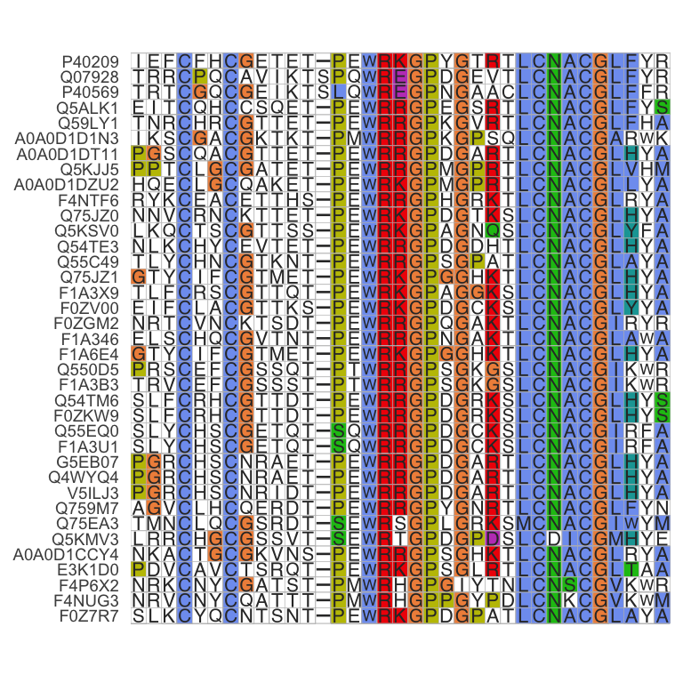

```r
seqs_full_gataonly_mafft_noseed %>%
  subseq(start = 1602, end = 1636) %>%
  ggmsa::ggmsa(color = "Clustal", seq_name = TRUE ) +
  theme(axis.text.x = element_blank(),
        axis.text.y = element_text(size = 7))
```

# Load the tree

Now we load the data.

```r
# load node labels
treedef <-
  here::here("results", "IQTREE",
             "output.treefile") %>%
  treeio::read.tree()
```

## Reroot to Amoebae ancestor

These trees were rooted to *C. neoformans* Gat201 so we reroot immediately to the amoebazoa ancestor, MRCA of all the Dictyostelium homologs.

```r
# find amoeba (DDB) homolog uniprot id
DDB_gataonly_uniprotIDs <-
  uniprot_df_gataonly %>%
  dplyr::filter( stringr::str_starts(GeneID, "DDB")  ) %>%
  dplyr::pull( UniprotID )

amoebae_MRCA <- MRCA(treedef, DDB_gataonly_uniprotIDs )

tree <- ape::root(treedef,
                       node=amoebae_MRCA)
```

## Plot tree rooted on Amoebae ancestor

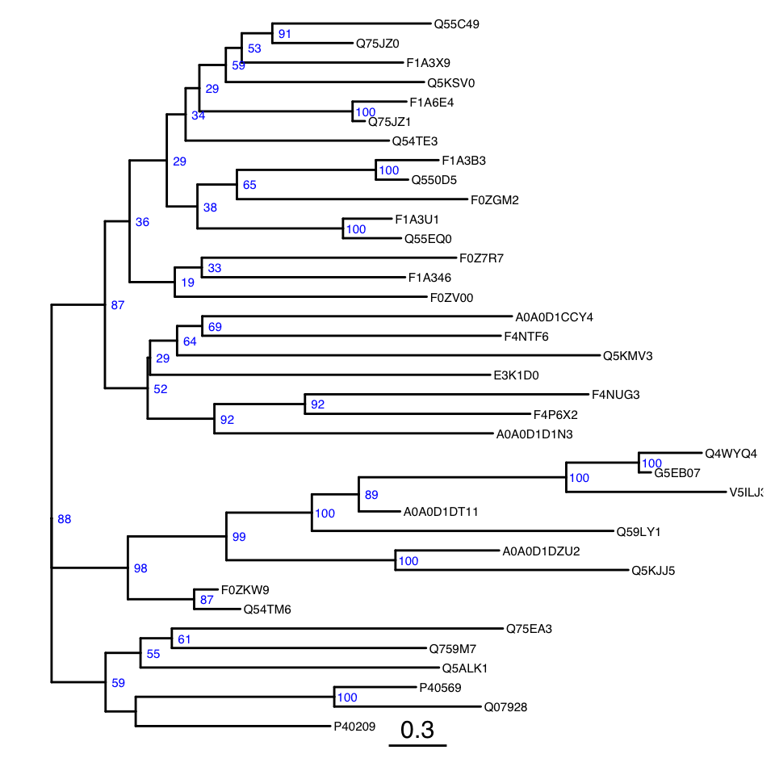

```r
ggtree(tree) +
    geom_tiplab(size=2) +
    geom_treescale(fontsize=4) +
    geom_nodelab(size=2,nudge_x=0.05,colour="blue")
```

## Join tree data and plot again

```r
tree_annotated <-
  full_join(tree,
            dplyr::rename(uniprot_df_gataonly, label = UniprotID))
```

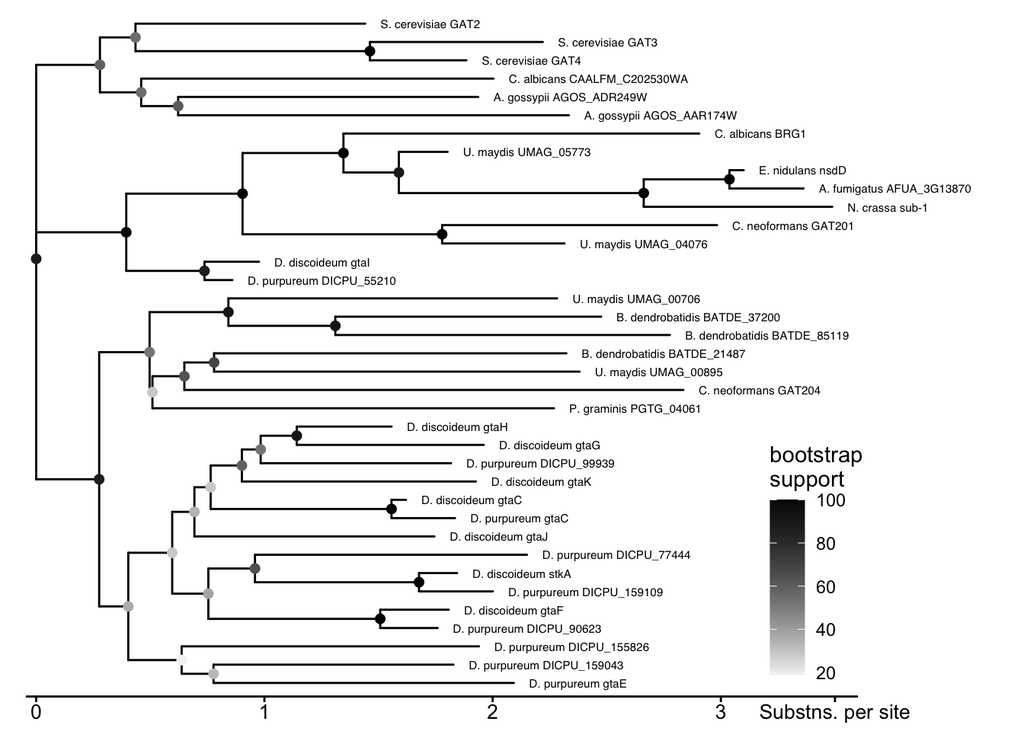

```r
ggt <-
  ggtree(tree_annotated, ladderize=FALSE)  +
    geom_tiplab(aes(label=DisplayName),
                size=2, key_glyph="rect",offset=0.05) +
    geom_nodepoint(aes(colour=as.numeric(label)),size=1.8) +
    scale_colour_gradient("bootstrap\nsupport",low="grey95",high="black",
                       guide = guide_colourbar(order = 2)) +
    scale_y_reverse(expand=c(0.02,0.02)) +
    scale_x_continuous(expand=c(0.01,0.01),
                       breaks=c(0:3,3.5),
                       labels=c(0:3,"Substns. per site")) +
    coord_cartesian(clip="off",) +
    theme(legend.position=c(0.95,0.2),
          plot.margin=margin(t=5,r = 82, b=5, l=10),
          axis.line.x.bottom = element_line(size=0.5,colour="black"),
          axis.ticks.x.bottom = element_line(size=0.5,colour="black"),
          axis.text.x = element_text(size=10,colour="black"))
ggt
```

## Reorder tree to show CnGAT201 at the top

Order tree (hand-encoded) in order: - C. neoformans GAT201 top - Then S.cerevisiae GAT2 - Then C. neoformans GAT204

```r
GAT201_MRCA <- MRCA(tree, "Q5KJJ5", "Q59LY1")
GAT201_parent <- MRCA(tree, "Q5KJJ5", "A0A0D1DZU2")
BRG1_parent <- MRCA(tree, "Q59LY1", "V5ILJ3")
GAT204_MRCA <- MRCA(tree, "Q5KMV3", "F4P6X2")
GAT204_node <- MRCA(tree, "Q5KMV3")
GAT204_sibling <- tidytree::sibling(tree, GAT204_node)

ScGAT2_MRCA <- MRCA(tree, "P40209", "Q75EA3")

GAT201_GAT2_MRCA <- MRCA(tree, GAT201_MRCA,ScGAT2_MRCA)

ggt_gat201top <-
  ggt %>%
  # put Gat201 clade top
  ggtree::flip(node1 = parent(tree,GAT201_MRCA), node2 = ScGAT2_MRCA) %>%
  # put Gat201 top of its clade
  ggtree::flip(node1 = GAT201_parent, node2 = BRG1_parent) %>%
  # put Gat204 top of its clade
  ggtree::flip(node1 = tidytree::child(tree, GAT204_MRCA)[1],
               node2 = tidytree::child(tree, GAT204_MRCA)[2]) %>%
  # put Gat204 top of its mini-branch
  ggtree::flip(node1 = GAT204_node, node2 = GAT204_sibling)
```

## Plot tree with clades nicely labeled

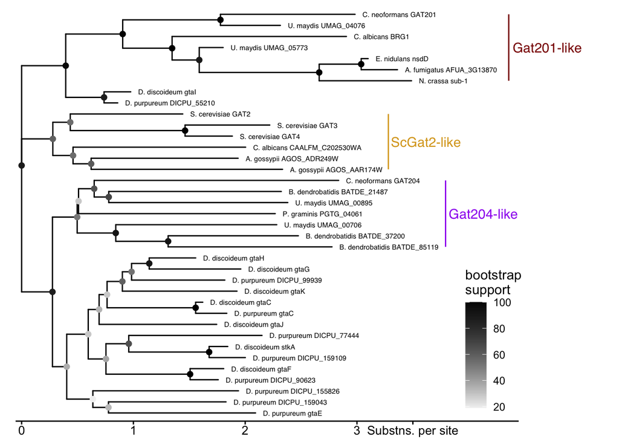

```r
ggt_clades <-
  ggt_gat201top +
  geom_cladelab( node = GAT201_MRCA, label = "Gat201-like",
                 offset = 0.8, geom = "text",
                 textcolor= "darkred", barcolour = "darkred") +
  geom_cladelab( node = GAT204_MRCA, label = "Gat204-like",
                 offset = 0.9, geom = "text",
                 textcolor= "purple", barcolour = "purple") +
  geom_cladelab( node = ScGAT2_MRCA, label = "ScGat2-like",
                 offset = 0.9, geom = "text",
                 textcolor= "goldenrod", barcolour = "goldenrod")

ggt_clades
```

## Get tips in order from tree

```r
uniprot_df_gataonly_treeorder <-
  ggt_gat201top$data %>%
  filter(isTip) %>%
  arrange(y)
```

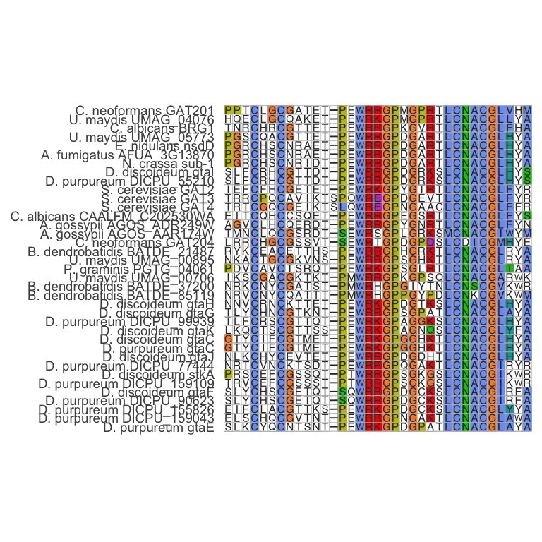

```r
msa_gatadomain_mafft_treeord <-
  seqs_full_gataonly_mafft_noseed %>%
  # select in order
  .[uniprot_df_gataonly_treeorder$label] %>%
  # rename with the slightly more informative names
  magrittr::set_names(uniprot_df_gataonly_treeorder$DisplayName) %>%
  subseq(start = 1602, end = 1636) %>%
  ggmsa::ggmsa(color = "Clustal", seq_name = TRUE ) +
  theme(axis.text.x = element_blank(),
        axis.text.y = element_text(size = 7))

msa_gatadomain_mafft_treeord
```

# Plot composite figure of tree and MSA

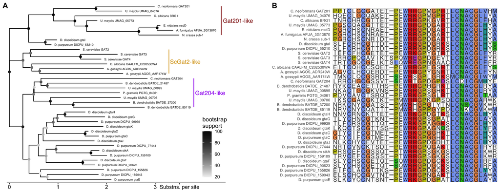

```r
cowplot::plot_grid(
  ggt_clades,
  msa_gatadomain_mafft_treeord,
  nrow = 1,
  rel_widths = c(7,6),
  labels="AUTO"
)
```

```r
here::here("results", "Gat201_pantherhomologs_treemsa.png") %>%
  ggsave(height = 5, width = 13, bg = "white")
```

# TO DO

- Add mafft terminal output to .html??
- Update README file to reflect new contents

# Session info for reproducibility

Note: I ran in to [known issues with `geom_cladelab`](https://github.com/YuLab-SMU/ggtree/issues/588).

I solved them by reinstalling tidytree and ggtree:

```r
devtools::install_version("tidytree", version = "0.4.2")
BiocManager::install("ggtree", force=T, type = 'source')
```